# Modeling Aboveground Biomass of Individual Trees in Pinyon-Juniper Woodlands

Jake Howell

2026-03-24

## 1 Script Purpose:

Here we present our methods estimating the Aboveground Biomass of Individual Trees within Pinyon-Juniper Woodlands. Using field data collected from 180 field plots, paired with two Canopy Height Model (CHM) sources.

Let’s begin by getting things set up.

Be sure the required packages are installed and libraries are loaded.

## 2 Set up

We’ll begin by setting the paths to our data. The required data are as follows

- Lidar-Derived Canopy Height Models (.tif)
- NAIP-derived Canopy Height Models (.tif)
- Spreadsheet of field plot data (.csv)
- Spreadsheet of tree level data (.csv)
- Spreadsheet of AGB equations (.csv)

Now let’s set our output paths

With our input and output data paths set, let’s now load in our data. Let’s start with the plot-level, lidar-derived CHM’s:

Let’s plot one to make sure it loaded correctly

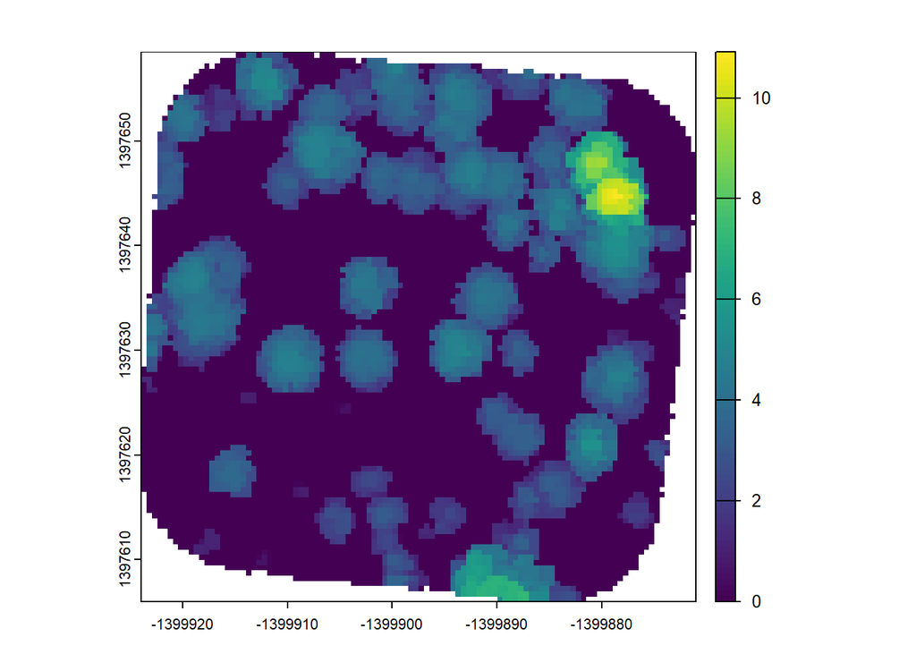

Now, read the site-level NAIP-derived CHMs:

We won’t plot the full NAIP CHM raster, but be sure there are 18 that loaded in

Finally, let’s load in the rest of our data that we need:

The plotData table contains the unique plot identification and GPS boundaries of the 180 field plots that were collected during the field campaign

```
##   OID_           src_name src_id      site_name   site_id plot_num
## 1    1 University of Utah   UOFU Cedar Fort, UT UOFU_UTCF        1
## 2    2 University of Utah   UOFU Cedar Fort, UT UOFU_UTCF        2
## 3    3 University of Utah   UOFU Cedar Fort, UT UOFU_UTCF        3
## 4    4 University of Utah   UOFU Cedar Fort, UT UOFU_UTCF        4
## 5    5 University of Utah   UOFU Cedar Fort, UT UOFU_UTCF        5
## 6    6 University of Utah   UOFU Cedar Fort, UT UOFU_UTCF        6
##         plot_id       date_time   plot_y    plot_x plot_ac  plot_shp plot_rad
## 1 UOFU_UTCF_P01  7/7/2022 14:44 40.28352 -112.1457     0.1 Rectangle       NA
## 2 UOFU_UTCF_P02  8/8/2022 18:51 40.28460 -112.1460     0.1 Rectangle       NA
## 3 UOFU_UTCF_P03  8/9/2022 15:00 40.29575 -112.1600     0.1 Rectangle       NA
## 4 UOFU_UTCF_P04  8/9/2022 19:20 40.30040 -112.1646     0.1 Rectangle       NA
## 5 UOFU_UTCF_P05 8/10/2022 15:10 40.25751 -112.1646     0.1 Rectangle       NA
## 6 UOFU_UTCF_P06 8/10/2022 18:26 40.26225 -112.1784     0.1 Rectangle       NA
##   plot_ne_y plot_ne_x plot_ne_ac plot_se_y plot_se_x plot_se_ac plot_sw_y
## 1  40.28365 -112.1455        0.1  40.28341 -112.1455        0.1  40.28339
## 2  40.28473 -112.1459        0.1  40.28446 -112.1459        0.1  40.28447
## 3  40.29589 -112.1598        0.1  40.29561 -112.1598        0.1  40.29562
## 4  40.30052 -112.1644        0.1  40.30027 -112.1644        0.1  40.30028
## 5  40.25764 -112.1644        0.1  40.25738 -112.1644        0.1  40.25739
## 6  40.26237 -112.1782        0.1  40.26211 -112.1782        0.1  40.26213
##   plot_sw_x plot_sw_ac plot_nw_y plot_nw_x plot_nw_ac site_notes plot_notes
## 1 -112.1459        0.1  40.28367 -112.1458      0.100
## 2 -112.1462        0.1  40.28474 -112.1462      0.100
## 3 -112.1602        0.1  40.29587 -112.1602      0.100
## 4 -112.1648        0.1  40.30054 -112.1648      0.100
## 5 -112.1648        0.1  40.25765 -112.1647      0.167
## 6 -112.1786        0.1  40.26239 -112.1786      0.100
```

The treeData table contains all the unique trees that were collected throughout the 180 field plots.

```
##   OID_      plot_id tree_num           tree_id tree_x tree_y tree_ac tree_sp
## 1    1 AND_UTRM_P01        1 AND_UTRM_P01_T001     NA     NA      NA    JUOS
## 2    2 AND_UTRM_P01        2 AND_UTRM_P01_T002     NA     NA      NA    JUOS
## 3    3 AND_UTRM_P01        3 AND_UTRM_P01_T003     NA     NA      NA    JUOS
## 4    4 AND_UTRM_P01        4 AND_UTRM_P01_T004     NA     NA      NA   FRAN2
## 5    5 AND_UTRM_P01        5 AND_UTRM_P01_T005     NA     NA      NA    JUOS
## 6    6 AND_UTRM_P01        6 AND_UTRM_P01_T006     NA     NA      NA    PIED
##   tree_cond tree_diam    tree_di_ht tree_notes
## 1      Live    55.118   Root Collar
## 2      Live    14.224   Root Collar
## 3      Live    85.598   Root Collar
## 4      Live     8.890 Breast Height
## 5      Live    82.296   Root Collar
## 6      Live    26.162   Root Collar
```

Finally, the biomassEquations table hosts species specific biomass equations that we’ll be applying to the individual field trees, which we can then summarize to get accurate plot-level AGB estimates.

## 3 Apply Biomass Equations to Field Data

Let’s apply the biomass equations. What we’re doing is using AGB-allometry to apply the species specific biomass equations to every tree that was collected within the field campaign.

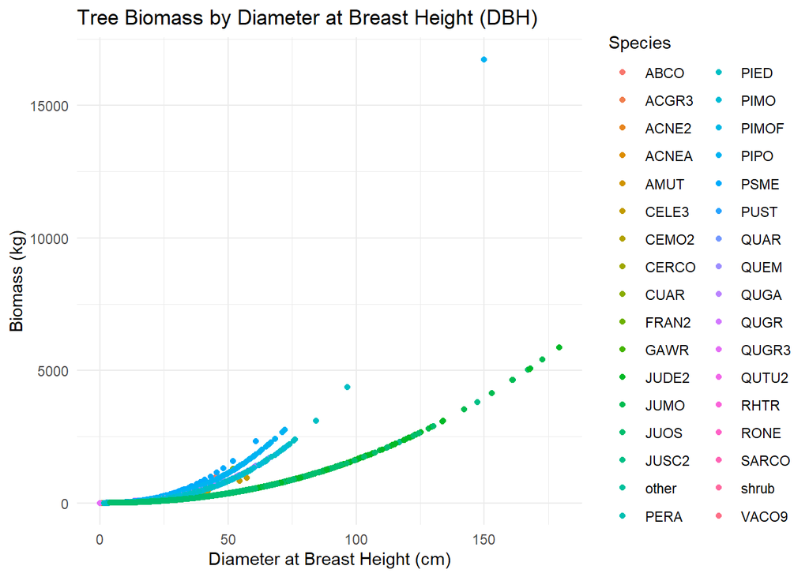

## 4 Create Field Plot Extents

Now let’s create our field plot extents. Our plotData table has the coordinates of the GPS points for our plot boundaries. We’ll coerce that into a geometric figure using those points.

We now have field plot extents for each one of our 180 field plots. These boundaries will serve as the spatial boundaries for performing individual tree detection.

## 5 Sum the Plot-Level Biomass

Now we can use the field extents and the individual tree AGB estimates to get plot-level AGB estimates for each of the 180 field plots.

Thus far, we’ve applied AGB equations to our field data trees and summarized those values at the plot-level to get total AGB for each of the 180 field plots.

We’ll now create our field plot extents for individual tree detection, which should optimally match the exact extent that field data was collected at.

We’ll loop through each of the 18 site-level NAIP-derived CHMs and clip them to the extent of the 180 field plots. We’ll also be sure to apply a 10-m buffer to each plot extent to ensure we properly capture every tree crown that was collected from the field data

And do the same for the plot-level lidar-derived CHMs

Now comes the fun part. We’ll now perform individual tree detection for both the NAIP-derived and Lidar-derived CHMs.

The chunk below is for tuning the tree detection and segmentation parameters for a single plot for the NAIP-derived CHM.

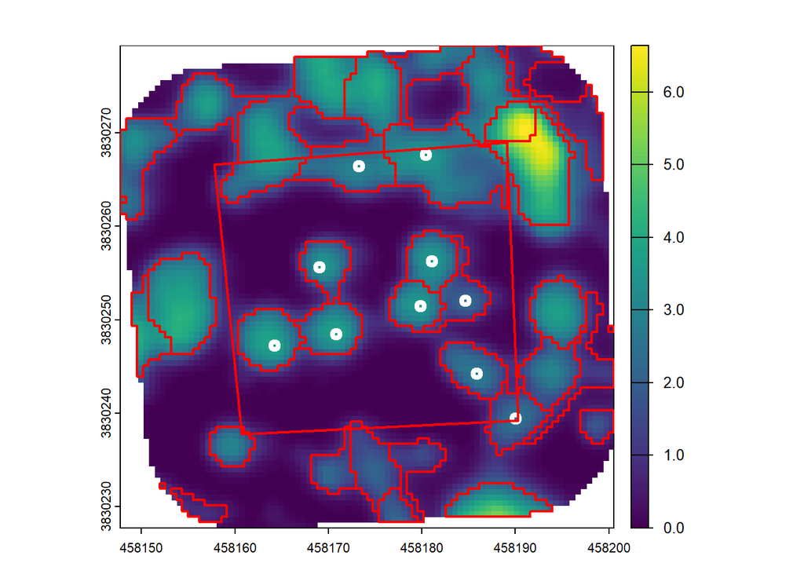

Now, tune the parameters on the lidar-derived tree list

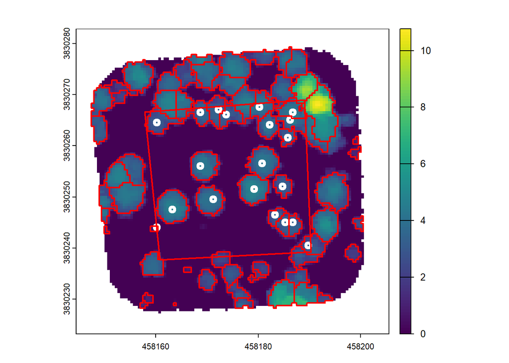

Once satisfied for parameters, run individual tree detection across the 180 plots for the NAIP-derived Canopy Height Models:

Then, run tree detection on the lidar-derived CHMs

We now have a tree list available for both the NAIP-derived and Lidar-Derived CHM.

Let’s check the results:

Map the NAIP layers:

```
## systemfonts and textshaping have been compiled with different versions of Freetype. Because of this, textshaping will not use the font cache provided by systemfonts
```

[interactive chart not shown]

Now plot the lidar data

[interactive chart not shown]

## 6 Model Biomass of Individual Trees

We’ll now use the metrics associated with the detected trees (tree height & crown area) to run numerical optimization. In essence, the individual tree-level predictor coefficients are tuned.

Let’s run it on the NAIP-derived tree list:

```
##         a         b         c
## 2.7420825 0.8398155 0.9631353
```

```
## UOFU_AZCV_P01 UOFU_AZCV_P02 UOFU_AZCV_P03 UOFU_AZCV_P04 UOFU_AZCV_P05
##     2298.2074     4244.9584     3542.1250     1679.3935     2334.9196
## UOFU_AZCV_P06 UOFU_AZCV_P07 UOFU_AZCV_P08 UOFU_AZCV_P09 UOFU_AZCV_P10
##     2573.3667     1672.7904     1663.6420     1431.3579     4149.8275
## UOFU_AZFL_P01 UOFU_AZFL_P02 UOFU_AZFL_P03 UOFU_AZFL_P04 UOFU_AZFL_P05
##     2173.7650     1766.7739     3170.2553      413.8732     4675.5281
## UOFU_AZFL_P06 UOFU_AZFL_P07 UOFU_AZFL_P08 UOFU_AZFL_P09 UOFU_AZFL_P10
##     2330.4513     2174.4370     1114.6024     1040.2376     2273.6620
## UOFU_AZFL_P11 UOFU_AZTU_P01 UOFU_AZTU_P02 UOFU_AZTU_P03 UOFU_AZTU_P04
##     1677.5608     1926.1421     3357.2441     6749.4524      772.2968
## UOFU_AZTU_P05 UOFU_AZTU_P06 UOFU_AZTU_P07 UOFU_AZTU_P08 UOFU_AZTU_P09
##     4900.8376     3978.5815     3391.7542     7149.1943     6837.4033
## UOFU_AZTU_P10 UOFU_AZTU_P11 UOFU_AZWI_P01 UOFU_AZWI_P02 UOFU_AZWI_P03
##     7144.7065     7115.7478      889.7381     2745.3964     4827.2509
## UOFU_AZWI_P04 UOFU_AZWI_P05 UOFU_AZWI_P06 UOFU_AZWI_P07 UOFU_AZWI_P08
##     5239.5171     4449.9853     5074.9040     3553.1038     3865.4059
## UOFU_AZWI_P09 UOFU_AZWI_P10 UOFU_AZWI_P11 UOFU_CODC_P01 UOFU_CODC_P02
##     2793.2490     1987.4453     1788.4015     6338.3126     6043.8456
## UOFU_CODC_P03 UOFU_CODC_P04 UOFU_CODC_P05 UOFU_CODC_P06 UOFU_CODC_P07
##     8738.8541      874.6994     5097.0033     1669.4438     5002.8064
## UOFU_CODC_P08 UOFU_CODC_P09 UOFU_CODC_P10 UOFU_COIG_P01 UOFU_COIG_P02
##     7188.5838     6715.2576     4164.2504     5519.2630     2813.2361
## UOFU_COIG_P03 UOFU_COIG_P04 UOFU_COIG_P05 UOFU_COIG_P06 UOFU_COIG_P07
##     4936.2123     5862.0624     4255.0427     1595.7129     3388.0951
## UOFU_COIG_P08 UOFU_COIG_P09 UOFU_COIG_P10 UOFU_NMER_P01 UOFU_NMER_P02
##     5619.4986     1992.5308     7454.1707      452.2654     2532.7221
## UOFU_NMER_P03 UOFU_NMER_P04 UOFU_NMER_P05 UOFU_NMER_P06 UOFU_NMER_P07
##     5585.6834     5050.1529     4807.3745      326.3508     3699.9047
## UOFU_NMER_P08 UOFU_NMMI_P01 UOFU_NMMI_P02 UOFU_NMMI_P03 UOFU_NMMI_P04
##     1974.6916     2697.4065     6503.7593     2573.6792     5757.8950
## UOFU_NMMI_P05 UOFU_NMMI_P06 UOFU_NMMI_P07 UOFU_NMMI_P08 UOFU_NMMI_P09
##     5673.2773     5925.2821     2725.7338     3175.3736     2260.6183
## UOFU_NMMI_P10 UOFU_NMMI_P11 UOFU_NMQU_P01 UOFU_NMQU_P02 UOFU_NMQU_P03
##     6319.9759     4804.0721     8104.9846     6924.3234     6307.2204
## UOFU_NMQU_P04 UOFU_NMQU_P05 UOFU_NMQU_P06 UOFU_NMQU_P07 UOFU_NMQU_P08
##     2745.7518     5578.4162     9090.7315     8358.5629     4689.3434
## UOFU_NMQU_P09 UOFU_NMQU_P10 UOFU_NMQU_P11 UOFU_NMQU_P12 UOFU_NMTY_P01
##      296.4100     2425.8033     2889.6706     4393.6667     7779.9649
## UOFU_NMTY_P02 UOFU_NMTY_P03 UOFU_NMTY_P04 UOFU_NMTY_P05 UOFU_NMTY_P06
##     5731.4091     6349.1879     6003.2875     7621.1747     4108.0599
```

[output cut: 17 more lines]

```
##     4143.8479      999.4788     2471.7647     2478.1240     6102.8345
## UOFU_UTGR_P06 UOFU_UTGR_P07 UOFU_UTGR_P08 UOFU_UTGR_P09 UOFU_UTGR_P10
##     3517.4496     1886.5802     3639.9165     6383.9654     4297.9467
## UOFU_UTGR_P11 UOFU_UTGR_P12 UOFU_UTGR_P13 UOFU_UTKA_P01 UOFU_UTKA_P02
##     2297.3298     4374.2895     6511.2137     2692.5398     4834.6175
## UOFU_UTKA_P03 UOFU_UTKA_P04 UOFU_UTKA_P05 UOFU_UTKA_P06 UOFU_UTKA_P07
##     3792.4163     1317.2298     3875.9011     1378.1033     2278.2103
## UOFU_UTKA_P08 UOFU_UTKA_P09 UOFU_UTKA_P10 UOFU_UTMO_P01 UOFU_UTMO_P02
##     2936.5457     5252.7081     4497.3793     5693.1439     6888.5950
## UOFU_UTMO_P03 UOFU_UTMO_P04 UOFU_UTMO_P05 UOFU_UTMO_P06 UOFU_UTMO_P08
##     7446.6215     3505.2040     1700.2253     6891.3224     6674.3435
## UOFU_UTMO_P09 UOFU_UTMO_P10 UOFU_UTPV_P01 UOFU_UTPV_P02 UOFU_UTPV_P03
##     5275.8734     2090.3460     4882.6984     4007.3220     7148.8744
## UOFU_UTPV_P04 UOFU_UTPV_P05 UOFU_UTPV_P06 UOFU_UTPV_P07
##     1041.9385      554.6370     1598.2514     5555.0421
```

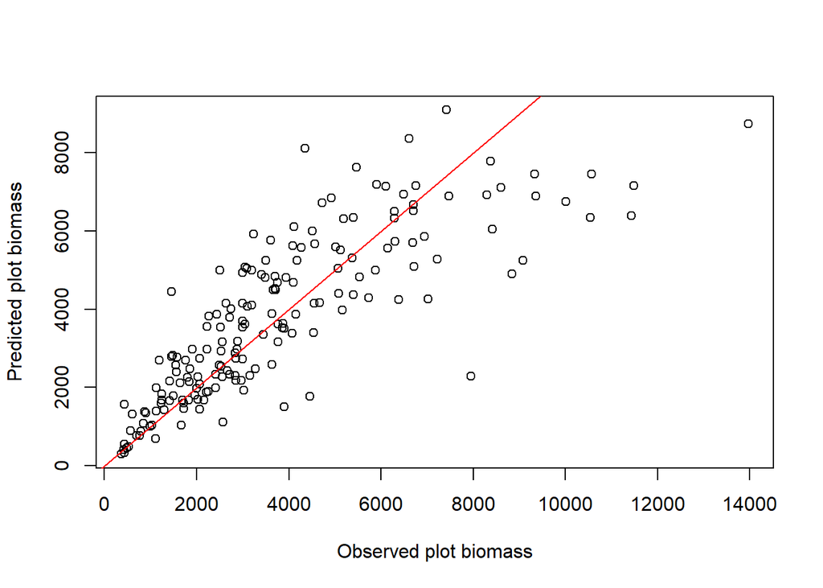

```
## [1] 1466.412
```

```
## [1] 1025.228
```

```
## [1] 0.6694634
```

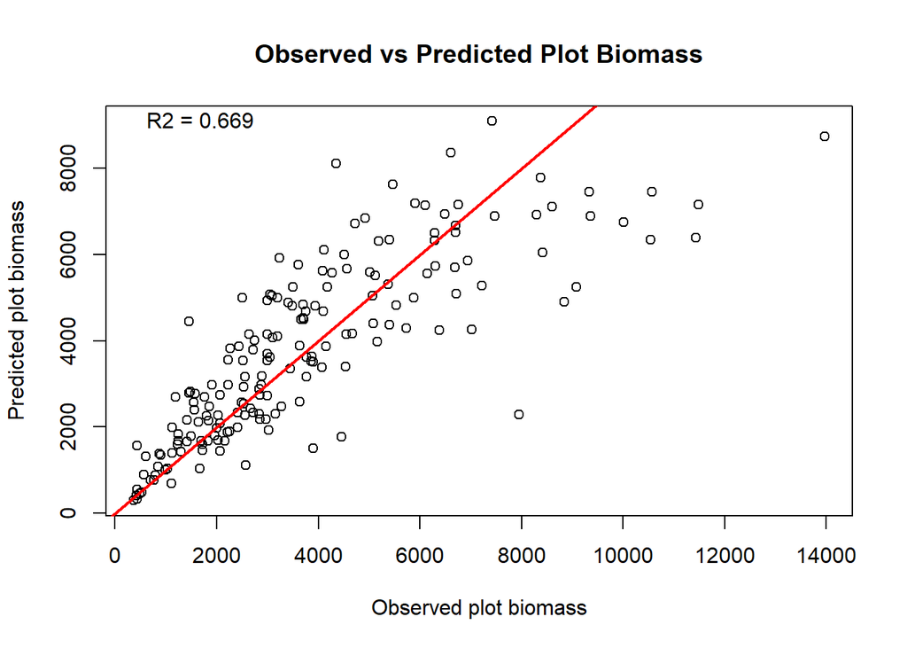

And the lidar-derived tree list

```
##         a         b         c
## 6.0657209 1.1433242 0.5651727
```

```
## UOFU_AZCV_P01 UOFU_AZCV_P02 UOFU_AZCV_P03 UOFU_AZCV_P04 UOFU_AZCV_P05
##     2779.7135     4481.7043     2708.9737     1799.1827     2634.1084
## UOFU_AZCV_P06 UOFU_AZCV_P07 UOFU_AZCV_P08 UOFU_AZCV_P09 UOFU_AZFL_P01
##     2811.1990     1201.9307     1343.5470     1512.0708     2290.6014
## UOFU_AZFL_P02 UOFU_AZFL_P03 UOFU_AZFL_P04 UOFU_AZFL_P05 UOFU_AZFL_P06
##     2883.9530     2965.1732      655.5438     3632.1857     3173.7642
## UOFU_AZFL_P07 UOFU_AZFL_P10 UOFU_AZTU_P01 UOFU_AZTU_P02 UOFU_AZTU_P03
##     2798.1821     1991.2305     2353.3201     4422.1542     7204.4875
## UOFU_AZTU_P04 UOFU_AZTU_P05 UOFU_AZTU_P06 UOFU_AZTU_P07 UOFU_AZTU_P08
##      615.9232     5922.7432     4675.9932     3164.8946     8562.9672
## UOFU_AZTU_P09 UOFU_AZTU_P10 UOFU_AZTU_P11 UOFU_AZWI_P01 UOFU_AZWI_P02
##     6210.8142     7347.8466     7745.2665      761.8633     2539.1677
## UOFU_AZWI_P03 UOFU_AZWI_P04 UOFU_AZWI_P05 UOFU_AZWI_P06 UOFU_AZWI_P07
##     5136.5933     5320.2389     2624.0977     3138.0398     3338.7918
## UOFU_AZWI_P08 UOFU_AZWI_P09 UOFU_AZWI_P10 UOFU_AZWI_P11 UOFU_CODC_P01
##     5609.2996     1717.1900     1838.6575     1688.8762     5377.7764
## UOFU_CODC_P02 UOFU_CODC_P03 UOFU_CODC_P04 UOFU_CODC_P05 UOFU_CODC_P06
##     5638.7126     9802.1731     1035.9787     5386.1136     2980.9892
## UOFU_CODC_P07 UOFU_CODC_P08 UOFU_CODC_P09 UOFU_CODC_P10 UOFU_COIG_P01
##     4094.4761     7429.9443     5985.2236      835.2742     4570.6948
## UOFU_COIG_P02 UOFU_COIG_P03 UOFU_COIG_P04 UOFU_COIG_P05 UOFU_COIG_P06
##     2002.8539     4750.0880     4663.3161     4369.3867     1818.4655
## UOFU_COIG_P07 UOFU_COIG_P08 UOFU_COIG_P09 UOFU_COIG_P10 UOFU_NMER_P01
##     3510.1213     5786.9126     1635.5525     7336.0483      440.9914
## UOFU_NMER_P02 UOFU_NMER_P03 UOFU_NMER_P04 UOFU_NMER_P05 UOFU_NMER_P06
##     2122.4857     5922.9702     4469.9519     4763.2450      780.9941
## UOFU_NMER_P07 UOFU_NMER_P08 UOFU_NMMI_P01 UOFU_NMMI_P02 UOFU_NMMI_P03
##     3682.1142     2047.7623     1997.3422     6992.9691     1241.8647
## UOFU_NMMI_P04 UOFU_NMMI_P05 UOFU_NMMI_P06 UOFU_NMMI_P07 UOFU_NMMI_P08
##     3956.2766     4435.6049     3400.2671     2344.2043     2331.7431
## UOFU_NMMI_P09 UOFU_NMMI_P10 UOFU_NMMI_P11 UOFU_NMQU_P01 UOFU_NMQU_P02
##     1476.9298     4507.4604     4415.5720     5914.2225     7303.4533
## UOFU_NMQU_P03 UOFU_NMQU_P04 UOFU_NMQU_P05 UOFU_NMQU_P06 UOFU_NMQU_P07
##     7657.6511     1633.1170     6204.3297     9698.1704     8233.2708
## UOFU_NMQU_P08 UOFU_NMQU_P09 UOFU_NMQU_P10 UOFU_NMQU_P11 UOFU_NMQU_P12
##     4995.5720      345.6395     2659.1471     3175.5843     5334.2493
## UOFU_NMTY_P01 UOFU_NMTY_P02 UOFU_NMTY_P03 UOFU_NMTY_P04 UOFU_NMTY_P05
##     9437.6477     6308.2031     7029.5947     5466.6991     5734.8663
## UOFU_NMTY_P06 UOFU_NMTY_P07 UOFU_NMTY_P08 UOFU_NMTY_P09 UOFU_NMTY_P10
##     4208.8985     1886.6729     1839.7132     3845.2139     3143.5774
```

[output cut: 17 more lines]

```
##     6040.0626     3721.4668     2347.7803     4816.8393     6852.1622
## UOFU_UTGR_P10 UOFU_UTGR_P11 UOFU_UTGR_P12 UOFU_UTGR_P13 UOFU_UTKA_P01
##     4529.8209     2264.3407     4965.0755     6914.5121     2384.0216
## UOFU_UTKA_P02 UOFU_UTKA_P03 UOFU_UTKA_P04 UOFU_UTKA_P05 UOFU_UTKA_P06
##     5038.5409     4375.4846     1032.7259     4026.6122     1484.2790
## UOFU_UTKA_P07 UOFU_UTKA_P08 UOFU_UTKA_P09 UOFU_UTKA_P10 UOFU_UTMO_P01
##     3713.9914     3133.3610     7060.5685     4666.2641     4505.9995
## UOFU_UTMO_P02 UOFU_UTMO_P03 UOFU_UTMO_P04 UOFU_UTMO_P05 UOFU_UTMO_P06
##     7176.5634     6871.8329     3244.6441     1848.6209     7463.0170
## UOFU_UTMO_P07 UOFU_UTMO_P08 UOFU_UTMO_P09 UOFU_UTMO_P10 UOFU_UTPV_P01
##     3034.4882     7145.1571     5099.4933     1996.7090     4763.8389
## UOFU_UTPV_P02 UOFU_UTPV_P03 UOFU_UTPV_P04 UOFU_UTPV_P05 UOFU_UTPV_P06
##     3718.1628     5963.9024     1085.5105      658.1676     1921.8799
## UOFU_UTPV_P07
##     5535.0694
```

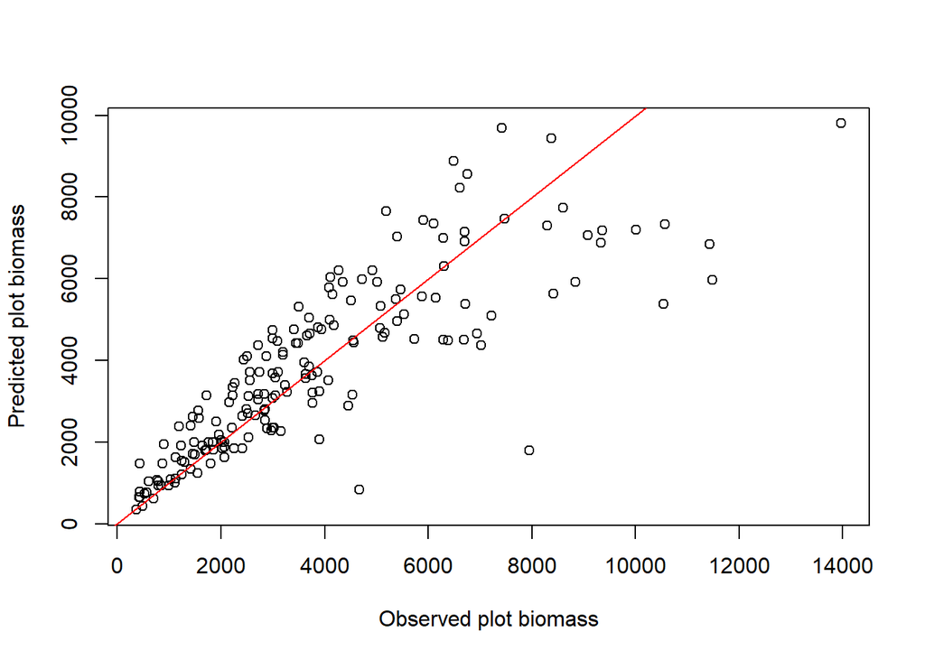

```
## [1] 1413.937
```

```
## [1] 953.7675
```

```
## [1] 0.6952868
```

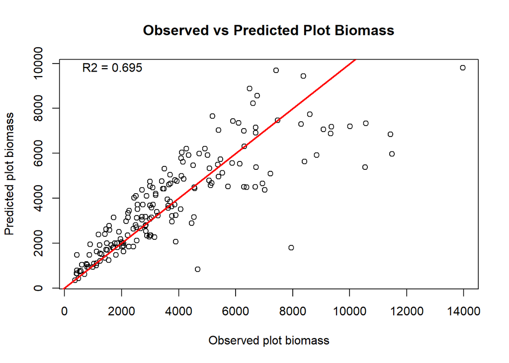